# Linear Regression Demo

We have a dataset as shown in the lecture to predict the house price.

```python
import pandas as pd
```

```python
df=pd.read_csv('housing.data')
```

```python
df.head()
```

|  | 0.00632 18.00 2.310 0 0.5380 6.5750 65.20 4.0900 1 296.0 15.30 396.90 4.98 24.00 |
| --- | --- |
| 0 | 0.02731 0.00 7.070 0 0.4690 6.4210 78... |
| 1 | 0.02729 0.00 7.070 0 0.4690 7.1850 61... |
| 2 | 0.03237 0.00 2.180 0 0.4580 6.9980 45... |
| 3 | 0.06905 0.00 2.180 0 0.4580 7.1470 54... |
| 4 | 0.02985 0.00 2.180 0 0.4580 6.4300 58... |

```python
df=pd.read_csv('housing.data',header=None,sep='\s+')
```

```python
df.columns=['CRIM','ZN','INDUS','CHAS','NOX','RM','AGE','DIS','PAD','TAX','PTRATIO','B','LSTAT','MEDV']
```

#### Column Information:

1. CRIM: per capita crime rate by town
2. ZN: proportion of residential land zoned for lots over 25,000 sq.ft.
3. INDUS: proportion of non-retail business acres per town
4. CHAS: Charles River dummy variable (= 1 if tract bounds river; 0 otherwise)
5. NOX: nitric oxides concentration (parts per 10 million)
6. RM: average number of rooms per dwelling
7. AGE: proportion of owner-occupied units built prior to 1940
8. DIS: weighted distances to five Boston employment centres
9. RAD: index of accessibility to radial highways
10. TAX: full-value property-tax rate per \$10,000
11. PTRATIO: pupil-teacher ratio by town
12. B: 1000(Bk - 0.63)^2 where Bk is the proportion of blacks by town
13. LSTAT: \% lower status of the population
14. MEDV: Median value of owner-occupied homes in $1000's!

```python
df.head()
```

|  | CRIM | ZN | INDUS | CHAS | NOX | RM | AGE | DIS | PAD | TAX | PTRATIO | B | LSTAT | MEDV |
| --- | --- | --- | --- | --- | --- | --- | --- | --- | --- | --- | --- | --- | --- | --- |
| 0 | 0.00632 | 18.0 | 2.31 | 0 | 0.538 | 6.575 | 65.2 | 4.0900 | 1 | 296.0 | 15.3 | 396.90 | 4.98 | 24.0 |
| 1 | 0.02731 | 0.0 | 7.07 | 0 | 0.469 | 6.421 | 78.9 | 4.9671 | 2 | 242.0 | 17.8 | 396.90 | 9.14 | 21.6 |
| 2 | 0.02729 | 0.0 | 7.07 | 0 | 0.469 | 7.185 | 61.1 | 4.9671 | 2 | 242.0 | 17.8 | 392.83 | 4.03 | 34.7 |
| 3 | 0.03237 | 0.0 | 2.18 | 0 | 0.458 | 6.998 | 45.8 | 6.0622 | 3 | 222.0 | 18.7 | 394.63 | 2.94 | 33.4 |
| 4 | 0.06905 | 0.0 | 2.18 | 0 | 0.458 | 7.147 | 54.2 | 6.0622 | 3 | 222.0 | 18.7 | 396.90 | 5.33 | 36.2 |

```python
print(df['CHAS'].value_counts())
print(df['PAD'].value_counts())
```

```
0    471
1     35
Name: CHAS, dtype: int64
24    132
5     115
4     110
3      38
6      26
8      24
2      24
1      20
7      17
Name: PAD, dtype: int64
```

Here, we see that **CHAS** and **PAD** are categorical features. We can either exclude them or we can make dummy variables for each.

- When there are more than two categories, we cannot simply code the variables by more integers, as scikit-learn estimators expects continuous input, and would interpret the categories as being ordered, which is often not desired.

### EDA

- we can explore correlations between features and also against the target.
- Here, we are going to find the correlation in this demo but usually this process requires handling missing values by imputation, feature engineering, for example, creating dummy variables for categorical features or reduce the number of features if we find any tight correlation among features.
- This process may repeated after traning the model.

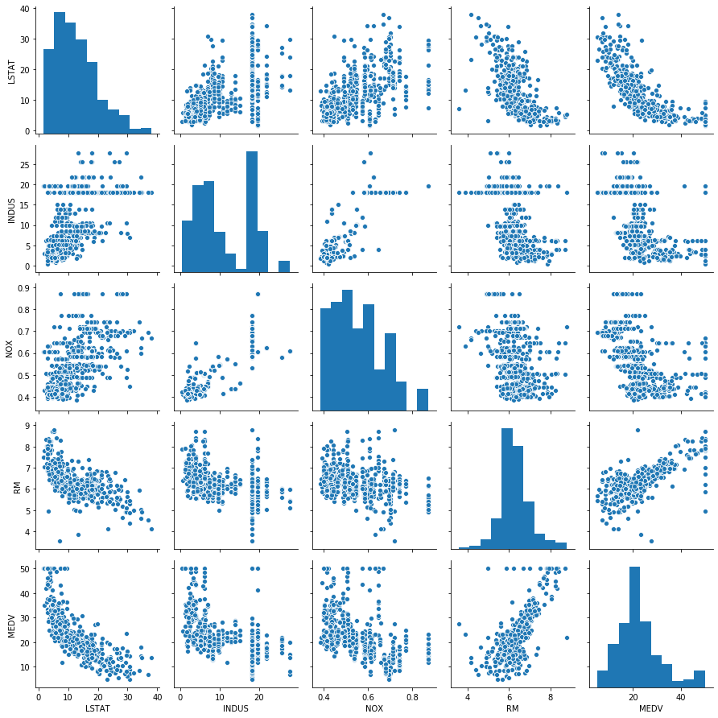

```python
import matplotlib.pyplot as plt
import seaborn as sns
cols=['LSTAT','INDUS','NOX','RM','MEDV']
sns.pairplot(df[cols],size=2.5)
plt.tight_layout()
plt.show()
```

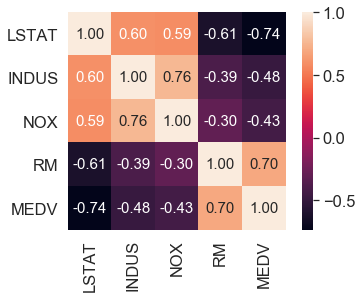

```python
import numpy as np
cm=np.corrcoef(df[cols].values.T)
sns.set(font_scale=1.5)
hm=sns.heatmap(cm,cbar=True,annot=True,square=True,fmt='.2f',annot_kws={'size':15},yticklabels=cols,xticklabels=cols)
plt.show()
```

From the correlation investigation, we find that **RM** has the strong correlation to **MEDV**,the target variable, and **LSTAT** has an inverse correlation. The correlation value implies which features are likely be dominated in traing process.

- Therefore, we are going to train the model using **RM** and **LSTAT** for the first trial, then gradually increase the number of features to examine and select the best model to do predict the final result.

### Training and Testing

1. **RM** Only
2. **RM** + **LSTAT**
3. Features in the diagram above
4. All continuous features

```python
from sklearn.model_selection import train_test_split
X=df[['RM']]
y=df.iloc[:,-1]
X_train, X_test, y_train, y_test = train_test_split(X, y, test_size=0.3, random_state=0)
```

```python
from sklearn.linear_model import LinearRegression
```

```python
slr=LinearRegression()
slr.fit(X_train, y_train)
```

```
LinearRegression(copy_X=True, fit_intercept=True, n_jobs=None, normalize=False)
```

```python
y_train_pred=slr.predict(X_train)
```

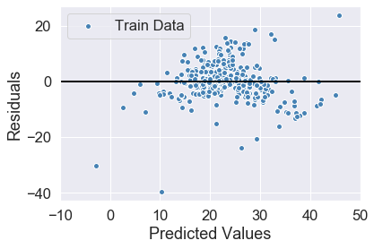

```python
plt.scatter(y_train_pred, y_train_pred-y_train,
           c='steelblue', marker='o',edgecolor='white', label='Train Data')
plt.xlabel('Predicted Values')
plt.ylabel('Residuals')
plt.legend(loc='upper left')
plt.hlines(y=0, xmin=-10, xmax=50, color='black',lw=2)
plt.xlim([-10,50])
plt.show()
```

```python
from sklearn.metrics import mean_squared_error
print('MSE train: %.3f' %(mean_squared_error(y_train,y_train_pred)))
#                                     mean_squared_error(y_test,y_test_pred)))
from sklearn.metrics import r2_score
print('R^2 train: %.3f' %(r2_score(y_train,y_train_pred)))
#                                     r2_score(y_test,y_test_pred)))
```

```
MSE train: 42.158
R^2 train: 0.503
```

The result above indicates that our first model is not good. See the note below for the interpretation.

### Evaluating the Model: Coefficient of Determination

- Once we fit a linear model, how should we assess the overall accuracy of the model?
- The usual way to measure the overall accuracy of a simple linear model is to use the **coefficient of determination**.
- The coefficient of determination, denoted $R^2$, measures how well a model fits the data.
- $R^2$ is defined as $$R^2=1-\frac{RSS}{TSS}$$ where TSS is the total sum of squares: $$TSS=\sum_{i=1}^{n}(y_i-\bar{y})^2$$
- RSS (The total area of the blue squares) represents the squared residuals with respect to the linear regression.
- TSS (The total area of the red squares) represents the squared residuals with respect to the average value and is fixed if data is known. (Can you tell why?)
- Therefore the coefficient of determination is a number $\in [0,1]$ that gauges the proportion of the variance in the dependent variable that is predictable from the independent variable.

[figure not shown]

*Source: https://en.wikipedia.org/wiki/Coefficient_of_determination. The areas of the red squares represent TSS. The areas of the blue squares represent RSS.*

- Given a dataset, TSS is model independent, the fitted model has the minimum RSS among all linear models:
  - $R^2 = 1$ indicates that the regression line fits the data perfectly (no error).
  - $R^2 = 0$ indicates that the line fits the data not better than the null model (horizontal $y=\bar{y})$.
  - In general, the better the linear regression fits the data in comparison to the sample average, the closer the value of $R^2$ is to 1.

```python
X=df[['RM','LSTAT']]
y=df.iloc[:,-1]
X_train, X_test, y_train, y_test = train_test_split(X, y, test_size=0.3, random_state=0)
slr=LinearRegression()
slr.fit(X_train, y_train)
```

```
LinearRegression(copy_X=True, fit_intercept=True, n_jobs=None, normalize=False)
```

```python
y_train_pred=slr.predict(X_train)
```

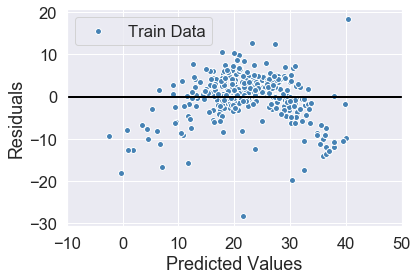

```python
plt.scatter(y_train_pred, y_train_pred-y_train,
           c='steelblue', marker='o',edgecolor='white', label='Train Data')
plt.xlabel('Predicted Values')
plt.ylabel('Residuals')
plt.legend(loc='upper left')
plt.hlines(y=0, xmin=-10, xmax=50, color='black',lw=2)
plt.xlim([-10,50])
plt.show()
```

```python
from sklearn.metrics import mean_squared_error
print('MSE train: %.3f' %(mean_squared_error(y_train,y_train_pred)))
#                                     mean_squared_error(y_test,y_test_pred)))
from sklearn.metrics import r2_score
print('R^2 train: %.3f' %(r2_score(y_train,y_train_pred)))
#                                     r2_score(y_test,y_test_pred)))
```

```
MSE train: 29.588
R^2 train: 0.651
```

Our second model $\beta_0$+$\beta_1$**RM**+$\beta_2$**LSTAT** model is better than the first model. Model1 was way simplified and therefore the model **underfitted**. Therefore, we are going to keep Model2. Let's see how our third model would look like.

```python
X=df[['LSTAT','INDUS','NOX','RM']]
y=df[['MEDV']]
X_train, X_test, y_train, y_test = train_test_split(X, y, test_size=0.3, random_state=0)
slr=LinearRegression()
slr.fit(X_train, y_train)
y_train_pred=slr.predict(X_train)
print('MSE train: %.3f' %(mean_squared_error(y_train,y_train_pred)))
#                                     mean_squared_error(y_test,y_test_pred)))
from sklearn.metrics import r2_score
print('R^2 train: %.3f' %(r2_score(y_train,y_train_pred)))
#                                     r2_score(y_test,y_test_pred)))
```

```
MSE train: 29.264
R^2 train: 0.655
```

When you compare Model2 and Model3, the number of features has been increaed from 2 to 4. However, in terms of MSE and $R^2$, we can see that there were no significant improvements. In this way, we say that the model is overfitted, meaning the model is **too complex** without a significant improvement. Therefore, we are going to reject Model3.

```python
X=df[['CRIM','ZN','INDUS','NOX','RM','AGE','DIS','TAX','PTRATIO','B','LSTAT']]
y=df['MEDV']
X_train, X_test, y_train, y_test = train_test_split(X, y, test_size=0.3, random_state=0)
slr=LinearRegression()
slr.fit(X_train, y_train)
y_train_pred=slr.predict(X_train)
from sklearn.metrics import mean_squared_error
print('MSE train: %.3f' %(mean_squared_error(y_train,y_train_pred)))
#                                     mean_squared_error(y_test,y_test_pred)))
from sklearn.metrics import r2_score
print('R^2 train: %.3f' %(r2_score(y_train,y_train_pred)))
#                                     r2_score(y_test,y_test_pred)))
```

```
MSE train: 21.045
R^2 train: 0.752
```

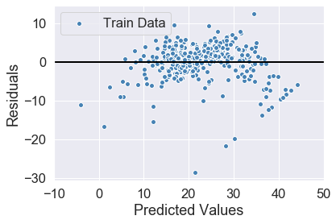

```python
plt.scatter(y_train_pred, y_train_pred-y_train,
           c='steelblue', marker='o',edgecolor='white', label='Train Data')
plt.xlabel('Predicted Values')
plt.ylabel('Residuals')
plt.legend(loc='upper left')
plt.hlines(y=0, xmin=-10, xmax=50, color='black',lw=2)
plt.xlim([-10,50])
plt.show()
```

Using all continuous features, we find that there were improvements. Despite Model4 is relatively complex than Model 2, still we find the improvements and to this end, we can choose Model4 among 4 models.

Now, we are going to apply to the test set and see the result.

```python
y_test_pred=slr.predict(X_test)
```

```python
print('MSE train: %.3f, test: %.3f' %(mean_squared_error(y_train,y_train_pred),
                                     mean_squared_error(y_test,y_test_pred)))
from sklearn.metrics import r2_score
print('MSE train: %.3f, test: %.3f' %(r2_score(y_train,y_train_pred),
                                     r2_score(y_test,y_test_pred)))
```

```
MSE train: 21.045, test: 29.626
MSE train: 0.752, test: 0.644
```